The goal of this notebook is to demonstrate how to obtain a superpixel segmentation of a raster and then store these as a vector format for visualization and later analyses.

A nice example of superpixel segmentation using the module we are using can be found [here](https://scikit-image.org/docs/dev/auto_examples/segmentation/plot_segmentations.html).

```python
import rasterio
import numpy as np
import matplotlib.pyplot as plt
from skimage.segmentation import felzenszwalb
from pathlib import Path
from skimage.color import label2rgb
import sys
sys.path.append('../../rscube')
from rio_tools import polygonize_array_to_shapefile
```

# Data Paths

```python
data_path_name = 'data/tif_datacube/'
data_path = Path(data_path_name)
data_path.exists()
```

```
True
```

```python
output_path_name = 'out'
out_path = Path(output_path_name)
out_path.mkdir(exist_ok=True, parents=True)
```

```python
tif_paths = sorted(list(data_path.glob('*.tif')))
tif_paths
```

```
[PosixPath('data/tif_datacube/ALOS_RTC_2009_06_30_HH.tif'),
 PosixPath('data/tif_datacube/ALOS_RTC_2009_06_30_HV.tif'),
 PosixPath('data/tif_datacube/Hansen_GFC2015_last_10N_000E.tif'),
 PosixPath('data/tif_datacube/Hansen_GFC2015_treecover2000_10N_000E.tif')]
```

# Visualizing the Landsat raster

We will use the landsat raster for visualization.

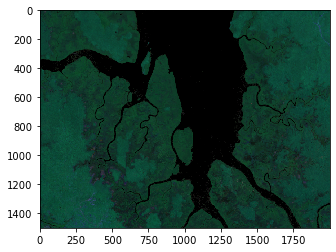

```python
with rasterio.open(tif_paths[2]) as ds:
    landsat_2015_mosaic_gdal = ds.read()
    landsat_2015_mosaic = landsat_2015_mosaic_gdal.transpose([1, 2, 0])
    profile = ds.profile
plt.imshow(landsat_2015_mosaic[..., :3])
```

```python
landsat_2015_mosaic_gdal.shape, landsat_2015_mosaic.shape
```

```
((4, 1500, 2000), (1500, 2000, 4))
```

The superpixel segmentation takes several parameters that can be read about in the [docs](https://scikit-image.org/docs/dev/api/skimage.segmentation.html#skimage.segmentation.felzenszwalb). To summarize, the `min_size` specifies the minimum size of all segments in the image, `scale` controls the approximate irregularity of the segments (precisely, a larger `scale` parameter determines if smaller sized segments are merged more easily during the formation of the final segmentation), and `sigma` is set to 0 so there is no smoothing done before segmentation.

```python
superpixel_labels = felzenszwalb(landsat_2015_mosaic,
                                 min_size=20,
                                 scale=.5,
                                 sigma=0,
                                 # The landsat mosaic has 4 channels
                                 multichannel=True,
                                 )
```

We can visualize the segments assigning random colors to each label.

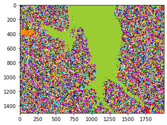

```python
superpixel_labels_rgb = label2rgb(superpixel_labels)
plt.imshow(superpixel_labels_rgb)
```

Now, we save the labels as polygons with each segment corresponding to a geometry.

```python
polygonize_array_to_shapefile(superpixel_labels, profile, out_path/'superpixels')
```